# M4T3 - Develop Models - Galaxy

## 4.4 KKNN Model

```r
## ------- KKNN------- ##

# set random seed
set.seed(123)

# KKNN train/fit
kknn_Fitg <- train(galaxysentiment~., data=gtrainSetN, method="kknn", trControl=fitControl, metric = "Kappa",tuneLength=5)
kknn_Fitg
```

```
k-Nearest Neighbors

9040 samples
  58 predictor
   6 classes: '0', '1', '2', '3', '4', '5'

No pre-processing
Resampling: Cross-Validated (5 fold)
Summary of sample sizes: 7232, 7232, 7232, 7232, 7232
Resampling results across tuning parameters:

  kmax  Accuracy   Kappa
   5    0.6018805  0.3633970
   7    0.7227876  0.4764412
   9    0.7300885  0.4857298
  11    0.6855088  0.4439092
  13    0.6868363  0.4450008

Tuning parameter 'distance' was held constant at a value of 2
Tuning parameter 'kernel' was held constant at a value of optimal
Kappa was used to select the optimal model using the largest value.
The final values used for the model were kmax = 9, distance = 2 and kernel = optimal.
```

```r
# Save the Model #
saveRDS(kknn_Fitg, "kknnFitg.rds")

# load and name model
kknn_Fitg<- readRDS("kknnFitg.rds")

#---Predict testSet with kknn---#

# predict with kknn
kknnPredg <- predict(kknn_Fitg, gtestSetN)
# print predictions
kknnPredg
```

```
   [1] 5 3 5 5 5 0 5 1 3 5 0 5 5 5 5 5 5 1 5 5 5 1 5 5 5 5 5 3 5 5 5 0 5 0 5 5 0 4 3 5 5 5 5 5 0 3 5 5 0 5 5 5 1 0 5 5 5 5 5 1 5 2 5
  [64] 0 5 5 5 5 5 5 5 5 5 5 5 5 5 5 5 5 5 5 5 4 5 5 5 5 0 5 5 3 5 5 5 3 0 5 5 5 5 0 5 5 5 0 3 5 5 5 1 5 5 5 5 3 5 1 5 5 0 5 5 0 1 5
 [127] 5 5 0 1 5 5 3 5 5 1 5 0 5 2 5 0 5 5 1 5 5 5 3 5 5 5 5 4 5 5 3 5 1 5 5 3 5 5 0 5 5 5 5 5 5 5 5 4 5 5 5 5 0 5 5 5 3 5 0 3 5 5 5
 [190] 5 5 5 5 5 1 1 5 5 5 5 5 5 5 5 5 0 5 5 5 5 3 5 5 0 5 5 5 0 5 0 3 3 0 3 5 5 5 3 5 1 5 5 5 5 5 5 4 5 0 0 1 5 0 5 5 3 3 0 0 5 5 5
 [253] 5 5 3 0 5 0 5 5 0 5 0 5 5 5 5 0 0 0 5 4 5 5 5 3 2 5 5 0 5 5 4 5 5 5 2 5 5 5 4 3 3 5 5 5 1 5 5 5 5 5 5 5 5 3 3 5 3 5 5 0 5 0 0
 [316] 5 5 5 5 5 5 3 5 5 5 1 3 5 4 5 1 1 4 5 3 5 1 5 4 5 5 5 5 4 5 5 1 3 5 5 0 4 5 5 5 1 5 0 5 5 0 5 3 5 1 5 5 5 5 5 5 4 1 5 0 5 5 0
 [379] 5 5 5 5 0 5 0 5 5 5 5 5 5 5 5 5 5 5 4 5 5 5 5 5 5 5 5 3 5 5 3 5 5 5 3 5 3 5 5 2 5 5 5 5 4 5 5 5 5 5 5 5 5 5 5 1 5 5 5 5 5 5 5
 [442] 5 5 5 5 5 5 1 5 5 5 5 5 5 5 5 1 5 5 0 5 5 0 1 3 0 0 5 0 1 5 1 5 1 5 0 5 5 5 5 5 5 5 5 5 1 5 5 5 5 5 5 5 5 5 5 5 5 5 5 5 5 5 5
 [505] 5 5 5 5 5 5 5 5 5 5 1 4 0 5 5 0 3 0 5 5 5 5 5 5 5 5 5 0 0 5 5 5 5 5 0 5 5 5 5 5 5 1 5 5 0 5 5 0 5 5 5 5 5 5 5 5 5 0 5 5 1 1 5
 [568] 5 5 5 4 0 0 0 5 5 5 1 5 4 5 5 1 5 5 5 5 5 5 5 5 2 5 5 1 5 5 5 0 1 5 1 5 4 5 5 0 3 0 3 5 3 5 3 5 5 5 5 5 3 5 5 5 5 5 0 1 5 3 5
 [631] 5 5 5 5 5 5 5 5 5 3 5 0 5 5 1 5 1 5 5 5 5 5 4 5 0 5 5 5 1 5 5 3 3 0 5 4 0 5 4 5 5 5 1 5 1 5 5 5 5 5 1 0 4 5 0 0 5 5 1 3 3 1 5
 [694] 0 0 1 5 5 5 5 1 1 3 5 5 5 5 5 5 5 5 5 5 5 0 5 3 5 5 0 5 5 5 5 5 5 1 0 5 5 1 5 5 0 5 5 3 5 5 5 1 5 5 4 0 4 3 4 5 5 5 5 5 1 1 5
 [757] 5 5 5 5 5 5 5 1 5 0 1 5 5 5 5 5 5 5 5 5 5 5 5 4 3 1 3 5 0 5 5 5 5 5 5 0 5 5 5 5 5 3 5 5 5 5 5 5 5 3 1 5 5 5 3 5 5 5 5 5 5 5 0
 [820] 5 5 5 5 5 0 5 0 5 1 5 5 5 1 5 5 5 0 5 5 0 5 5 0 5 5 5 5 0 5 5 5 5 0 0 5 0 0 1 5 0 5 5 5 5 5 1 5 5 1 0 4 5 3 5 3 5 1 5 5 2 1 4
 [883] 5 5 5 4 5 1 3 5 5 5 5 4 5 5 5 1 3 5 5 5 5 5 5 5 5 5 5 5 5 5 4 5 5 2 3 5 5 5 5 5 5 3 5 5 5 5 5 5 5 5 5 5 5 0 5 5 3 5 5 3 3 5 1
```

[output cut: 48 more lines]

```r
#summarize predictions
summary(kknnPredg)
```

```
   0    1    2    3    4    5
 423  275   32  271  164 2706
```

```r
#performance measurement
postResample(kknnPredg, gtestSetN$galaxysentiment)
```

```
 Accuracy     Kappa
0.6980108 0.4511633
```

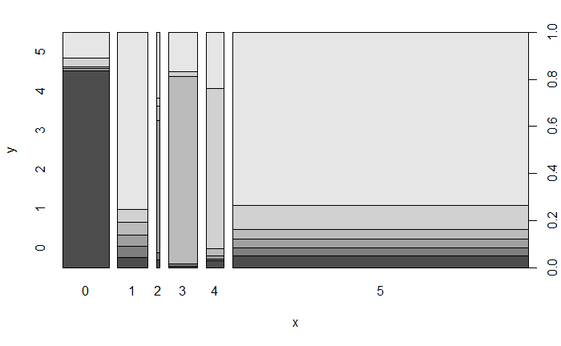

```r
# plot
plot(kknnPredg,gtestSetN$galaxysentiment)
```

```r
#calculate confusion Matrix
cmkknng <-confusionMatrix(kknnPredg, gtestSetN$galaxysentiment)
cmkknng
```

```
Confusion Matrix and Statistics

          Reference
Prediction    0    1    2    3    4    5
         0  353    1    4    3   15   47
         1   12   13   13   15   15  207
         2    1    1   18    2    1    9
         3    1    3    0  216    6   45
         4    5    1    2    5  112   39
         5  136   95   98  111  276 1990

Overall Statistics

               Accuracy : 0.698
                 95% CI : (0.6833, 0.7124)
    No Information Rate : 0.6037
    P-Value [Acc > NIR] : < 2.2e-16

                  Kappa : 0.4512

 Mcnemar's Test P-Value : < 2.2e-16

Statistics by Class:

                     Class: 0 Class: 1 Class: 2 Class: 3 Class: 4 Class: 5
Sensitivity           0.69488 0.114035 0.133333  0.61364  0.26353   0.8515
Specificity           0.97919 0.930264 0.996253  0.98437  0.98491   0.5332
Pos Pred Value        0.83452 0.047273 0.562500  0.79705  0.68293   0.7354
Neg Pred Value        0.95505 0.971913 0.969523  0.96222  0.91557   0.7021
Prevalence            0.13123 0.029450 0.034875  0.09093  0.10979   0.6037
Detection Rate        0.09119 0.003358 0.004650  0.05580  0.02893   0.5141
Detection Prevalence  0.10927 0.071041 0.008267  0.07001  0.04237   0.6990
Balanced Accuracy     0.83703 0.522149 0.564793  0.79900  0.62422   0.6924
```

## 4.5 GBM Model

```r
## ------- GBM------- ##

#recode variable of training set
gtrainSetNG <-gtrainSetN
gtrainSetNG$galaxysentiment <- recode(gtrainSetN$galaxysentiment, '0' = 'seg0', '1' = 'seg1', '2' = 'seg2', '3' = 'seg3', '4' = 'seg4', '5' = 'seg5')
str(gtrainSetNG)
```

```
'data.frame':   9040 obs. of  59 variables:
 $ iphone         : num  -0.1992 -0.1992 -0.1992 -0.3639 -0.0345 ...
 $ samsunggalaxy  : num  -0.254 -0.254 3.302 -0.254 -0.254 ...
 $ sonyxperia     : num  -0.14 -0.14 -0.14 -0.14 -0.14 ...
 $ nokialumina    : num  -0.0453 -0.0453 -0.0453 -0.0453 -0.0453 ...
 $ htcphone       : num  -0.0325 -0.0325 -0.0325 0.2037 -0.0325 ...
 $ ios            : num  -0.182 -0.182 -0.182 -0.182 -0.182 ...
 $ googleandroid  : num  -0.156 -0.156 -0.156 -0.156 -0.156 ...
 $ iphonecampos   : num  -0.132 -0.132 0.324 -0.132 0.324 ...
 $ samsungcampos  : num  -0.0754 -0.0754 1.3288 -0.0754 -0.0754 ...
 $ sonycampos     : num  -0.0606 -0.0606 -0.0606 -0.0606 -0.0606 ...
 $ nokiacampos    : num  -0.0302 -0.0302 -0.0302 -0.0302 -0.0302 ...
 $ htccampos      : num  -0.0706 -0.0706 -0.0706 -0.0706 -0.0706 ...
 $ iphonecamneg   : num  -0.246 -0.246 -0.246 -0.246 -0.246 ...
 $ samsungcamneg  : num  -0.103 -0.103 -0.103 -0.103 -0.103 ...
```

[output cut: 45 more lines]

```r
#recode variable of test set
gtestSetNG <-gtestSetN
gtestSetNG$galaxysentiment <- recode(gtestSetNG$galaxysentiment, '0' = 'seg0', '1' = 'seg1', '2' = 'seg2', '3' = 'seg3', '4' = 'seg4', '5' = 'seg5')
str(gtestSetNG)
```

```
'data.frame':   3871 obs. of  59 variables:
 $ iphone         : num  -0.199 -0.199 -0.199 0.46 -0.199 ...
 $ samsunggalaxy  : num  -0.254 -0.254 -0.254 -0.254 -0.254 ...
 $ sonyxperia     : num  -0.14 -0.14 -0.14 -0.14 -0.14 ...
 $ nokialumina    : num  -0.0453 -0.0453 -0.0453 -0.0453 -0.0453 ...
 $ htcphone       : num  -0.0325 -0.0325 -0.0325 -0.0325 -0.0325 ...
 $ ios            : num  -0.182 -0.182 -0.182 -0.182 -0.182 ...
 $ googleandroid  : num  -0.156 -0.156 -0.156 -0.156 -0.156 ...
 $ iphonecampos   : num  -0.132 -0.132 -0.132 -0.132 -0.132 ...
 $ samsungcampos  : num  -0.0754 -0.0754 -0.0754 -0.0754 -0.0754 ...
 $ sonycampos     : num  -0.0606 -0.0606 -0.0606 -0.0606 -0.0606 ...
 $ nokiacampos    : num  -0.0302 -0.0302 -0.0302 -0.0302 -0.0302 ...
 $ htccampos      : num  -0.0706 -0.0706 -0.0706 -0.0706 -0.0706 ...
 $ iphonecamneg   : num  -0.246 -0.246 -0.246 -0.246 -0.246 ...
 $ samsungcamneg  : num  -0.103 -0.103 -0.103 -0.103 -0.103 ...
```

[output cut: 45 more lines]

```r
# set random seed
set.seed(123)
# GBM train/fit
gmodel3<- train(galaxysentiment~., data=gtrainSetNG,method='gbm',trControl = fitControl,verbose=F,tuneLength=3)
gmodel3
```

```
Stochastic Gradient Boosting

9040 samples
  58 predictor
   6 classes: 'seg0', 'seg1', 'seg2', 'seg3', 'seg4', 'seg5'

No pre-processing
Resampling: Cross-Validated (5 fold)
Summary of sample sizes: 7232, 7232, 7232, 7232, 7232
Resampling results across tuning parameters:

  interaction.depth  n.trees  Accuracy   Kappa
  1                   50      0.7169248  0.4013864
  1                  100      0.7360619  0.4526381
  1                  150      0.7456858  0.4775455
  2                   50      0.7465708  0.4799495
  2                  100      0.7472345  0.4824071
  2                  150      0.7539823  0.5014272
  3                   50      0.7501106  0.4897346
  3                  100      0.7601770  0.5160744
  3                  150      0.7650442  0.5293069

Tuning parameter 'shrinkage' was held constant at a value of 0.1
Tuning parameter 'n.minobsinnode' was held constant at a value
 of 10
Accuracy was used to select the optimal model using the largest value.
The final values used for the model were n.trees = 150, interaction.depth = 3, shrinkage = 0.1 and n.minobsinnode = 10.
```

```r
# Save the Model #

saveRDS(gmodel3, "gbmFit3g.rds")

# load and name model
gbm_Fit3g<- readRDS("gbmFit3g.rds")

#---Predict testSet---#

# predict with gbm
gbmPred1g <- predict(gbm_Fit3g, gtestSetNG)

# print predictions
gbmPred1g
```

```
   [1] seg5 seg3 seg5 seg5 seg5 seg0 seg5 seg5 seg3 seg5 seg0 seg5 seg5 seg5 seg5 seg5 seg5 seg5 seg5 seg5 seg5 seg5 seg5 seg5 seg5
  [26] seg5 seg5 seg5 seg5 seg5 seg5 seg0 seg5 seg0 seg5 seg5 seg0 seg4 seg3 seg5 seg5 seg5 seg5 seg5 seg0 seg3 seg5 seg5 seg0 seg5
  [51] seg5 seg5 seg5 seg0 seg4 seg5 seg5 seg5 seg5 seg5 seg5 seg5 seg5 seg0 seg5 seg5 seg5 seg5 seg5 seg5 seg5 seg5 seg5 seg5 seg5
  [76] seg5 seg5 seg5 seg5 seg5 seg5 seg5 seg5 seg5 seg5 seg5 seg5 seg5 seg5 seg5 seg5 seg3 seg5 seg5 seg5 seg4 seg0 seg5 seg5 seg5
 [101] seg5 seg0 seg5 seg5 seg5 seg0 seg3 seg5 seg5 seg5 seg5 seg5 seg5 seg5 seg5 seg5 seg5 seg5 seg5 seg5 seg0 seg5 seg5 seg0 seg5
 [126] seg5 seg5 seg5 seg0 seg5 seg5 seg5 seg3 seg5 seg5 seg5 seg5 seg0 seg5 seg5 seg5 seg0 seg5 seg5 seg5 seg5 seg5 seg5 seg3 seg5
 [151] seg5 seg5 seg5 seg4 seg5 seg5 seg3 seg5 seg5 seg5 seg5 seg5 seg5 seg5 seg0 seg5 seg5 seg5 seg5 seg5 seg5 seg5 seg5 seg4 seg5
 [176] seg5 seg5 seg5 seg5 seg5 seg5 seg5 seg3 seg5 seg0 seg3 seg5 seg5 seg5 seg5 seg5 seg5 seg5 seg5 seg5 seg5 seg5 seg5 seg5 seg5
 [201] seg5 seg5 seg5 seg5 seg5 seg0 seg5 seg5 seg5 seg5 seg5 seg5 seg5 seg0 seg5 seg5 seg5 seg0 seg5 seg0 seg3 seg5 seg0 seg3 seg5
 [226] seg4 seg5 seg3 seg5 seg5 seg5 seg5 seg5 seg5 seg5 seg5 seg4 seg5 seg0 seg0 seg5 seg5 seg5 seg5 seg5 seg5 seg5 seg5 seg0 seg5
 [251] seg5 seg5 seg5 seg5 seg3 seg0 seg5 seg0 seg5 seg5 seg0 seg5 seg0 seg5 seg5 seg5 seg5 seg0 seg0 seg0 seg5 seg5 seg5 seg5 seg5
 [276] seg3 seg5 seg5 seg5 seg4 seg5 seg5 seg4 seg5 seg5 seg5 seg2 seg5 seg5 seg5 seg4 seg3 seg3 seg5 seg5 seg5 seg5 seg5 seg3 seg5
 [301] seg5 seg5 seg5 seg5 seg5 seg3 seg5 seg5 seg3 seg5 seg5 seg0 seg5 seg0 seg0 seg5 seg5 seg5 seg5 seg5 seg5 seg3 seg5 seg5 seg5
 [326] seg5 seg3 seg5 seg4 seg5 seg5 seg5 seg5 seg5 seg3 seg5 seg5 seg5 seg4 seg5 seg5 seg5 seg5 seg4 seg5 seg5 seg5 seg5 seg5 seg5
 [351] seg0 seg4 seg5 seg5 seg5 seg5 seg5 seg0 seg5 seg5 seg0 seg5 seg3 seg5 seg5 seg5 seg5 seg5 seg5 seg5 seg5 seg4 seg5 seg5 seg0
```

[output cut: 141 more lines]

```r
# summarize predictions
summary(gbmPred1g)
```

```
seg0 seg1 seg2 seg3 seg4 seg5
 390    1   18  252  135 3075
```

```r
# performance measurement
postResample(gbmPred1g, gtestSetNG$galaxysentiment)
```

```
 Accuracy     Kappa
0.7706019 0.5386981
```

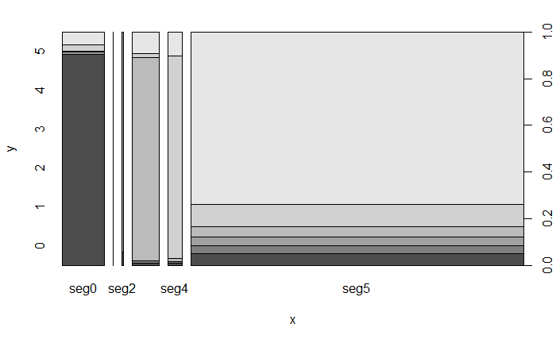

```r
# plot
plot(gbmPred1g,gtestSetN$galaxysentiment)
```

```r
#calculate confusion Matrix
cmgbmg <-confusionMatrix(gbmPred1g, gtestSetNG$galaxysentiment, mode="everything")
cmgbmg
```

```
Confusion Matrix and Statistics

          Reference
Prediction seg0 seg1 seg2 seg3 seg4 seg5
      seg0  353    0    3    2   10   22
      seg1    0    0    0    0    0    1
      seg2    1    0   17    0    0    0
      seg3    2    3    0  219    5   23
      seg4    1    1    0    2  117   14
      seg5  151  110  115  129  293 2277

Overall Statistics

               Accuracy : 0.7706
                 95% CI : (0.757, 0.7838)
    No Information Rate : 0.6037
    P-Value [Acc > NIR] : < 2.2e-16

                  Kappa : 0.5387

 Mcnemar's Test P-Value : NA

Statistics by Class:

                     Class: seg0 Class: seg1 Class: seg2 Class: seg3 Class: seg4 Class: seg5
Sensitivity              0.69488   0.0000000    0.125926     0.62216     0.27529      0.9743
Specificity              0.98900   0.9997338    0.999732     0.99062     0.99478      0.4798
Pos Pred Value           0.90513   0.0000000    0.944444     0.86905     0.86667      0.7405
Neg Pred Value           0.95547   0.9705426    0.969375     0.96325     0.91756      0.9246
Precision                0.90513   0.0000000    0.944444     0.86905     0.86667      0.7405
Recall                   0.69488   0.0000000    0.125926     0.62216     0.27529      0.9743
F1                       0.78619         NaN    0.222222     0.72517     0.41786      0.8415
Prevalence               0.13123   0.0294498    0.034875     0.09093     0.10979      0.6037
Detection Rate           0.09119   0.0000000    0.004392     0.05657     0.03022      0.5882
Detection Prevalence     0.10075   0.0002583    0.004650     0.06510     0.03487      0.7944
Balanced Accuracy        0.84194   0.4998669    0.562829     0.80639     0.63504      0.7271
```

# 5 Metrics Comparison

Find the best combination of data set and algorithm as measured by resulting performance metrics

```r
ModelFitResultsg <- resamples(list(C5.0=C5.0_Fitg,rf=rf_Fitg,SVM=svm_Fitg,kknn=kknn_Fitg,gbm=gbm_Fit3g))
# output summary metrics for tuned models
summary(ModelFitResultsg)
```

```
Call:
summary.resamples(object = ModelFitResultsg)

Models: C5.0, rf, SVM, kknn, gbm
Number of resamples: 5

Accuracy
          Min.   1st Qu.    Median      Mean   3rd Qu.      Max. NA's
C5.0 0.7605088 0.7616150 0.7638274 0.7641593 0.7660398 0.7688053    0
rf   0.7588496 0.7616150 0.7676991 0.7657080 0.7682522 0.7721239    0
SVM  0.6852876 0.6991150 0.7018805 0.7024336 0.7035398 0.7223451    0
kknn 0.6913717 0.7063053 0.7472345 0.7300885 0.7516593 0.7538717    0
gbm  0.7577434 0.7649336 0.7654867 0.7650442 0.7660398 0.7710177    0

Kappa
          Min.   1st Qu.    Median      Mean   3rd Qu.      Max. NA's
C5.0 0.5201444 0.5211200 0.5266023 0.5269740 0.5285588 0.5384445    0
rf   0.5139824 0.5189964 0.5359479 0.5308090 0.5365963 0.5485222    0
SVM  0.3319280 0.3666704 0.3781816 0.3764809 0.3889450 0.4166797    0
kknn 0.4334440 0.4596445 0.5081411 0.4857298 0.5111993 0.5162200    0
gbm  0.5109802 0.5248205 0.5320860 0.5293069 0.5335027 0.5451451    0
```

# 6 Feature Selection

You will then model with each of these new data sets to determine which method, if any, provides the best model accuracy for this project.

## 6.1 Method 1 - Correlation

```r
#####################################
# RF Model - Method 1 - Correlation #
#####################################

options(max.print=1000000)
galaxyCOR <- galaxy_smallmatrix_N
corrAll <- cor(galaxyCOR[,1:58])
corrAll
```

```
                    iphone samsunggalaxy   sonyxperia   nokialumina      htcphone           ios googleandroid iphonecampos
iphone         1.000000000  0.0159758824 -0.012286712 -0.0130113124 -0.0028618099  0.9281716877  9.911322e-02  0.076295824
samsunggalaxy  0.015975882  1.0000000000  0.365927086 -0.0061241775  0.0178484527 -0.0447752032  2.365132e-01  0.030226679
sonyxperia    -0.012286712  0.3659270858  1.000000000 -0.0063682064  0.0236093137 -0.0239166212 -1.831529e-02  0.004342369
nokialumina   -0.013011312 -0.0061241775 -0.006368206  1.0000000000  0.0006693785 -0.0028437199 -1.135554e-03  0.029849094
htcphone      -0.002861810  0.0178484527  0.023609314  0.0006693785  1.0000000000 -0.0050083453  1.650547e-02  0.006914218
ios            0.928171688 -0.0447752032 -0.023916621 -0.0028437199 -0.0050083453  1.0000000000 -2.645746e-02  0.042260679
googleandroid  0.099113220  0.2365132133 -0.018315293 -0.0011355541  0.0165054715 -0.0264574584  1.000000e+00  0.104609347
iphonecampos   0.076295824  0.0302266793  0.004342369  0.0298490944  0.0069142178  0.0422606790  1.046093e-01  1.000000000
samsungcampos  0.052992160  0.2511875267  0.047772377  0.0093131738  0.0107830524 -0.0107193160  3.160916e-01  0.061825315
sonycampos    -0.004962867  0.1431586761  0.395698570 -0.0027457373  0.0102814297 -0.0092775647  6.317932e-05  0.042839287
nokiacampos   -0.008197756 -0.0004208775 -0.004243949  0.7004134278  0.0004621265  0.0054129748  3.273148e-03  0.030839160
htccampos      0.020662226  0.0647274234  0.015445636  0.0213055121  0.0231129614 -0.0123667236  1.482689e-01  0.623980191
iphonecamneg   0.486838671  0.1265807721 -0.006595570  0.0633581661  0.0141257805  0.3879441309  3.927864e-01  0.541255338
samsungcamneg  0.132278137  0.3431998318 -0.004337150  0.0095239562  0.0200135867 -0.0153334136  7.118048e-01  0.117535498
sonycamneg    -0.001986513  0.0318343254  0.345739434 -0.0012347698  0.0049067382 -0.0038696843  1.353562e-02  0.020010336
nokiacamneg   -0.008912908 -0.0010016290 -0.004480128  0.7294325660  0.0001884590  0.0046379734 -1.839050e-03  0.026876038
htccamneg      0.096622616  0.2233020453 -0.012283129  0.0372938000  0.0367102562 -0.0230771581  5.637609e-01  0.206429162
iphonecamunc   0.753152812 -0.0105756133 -0.008327405  0.0162333473  0.0011359968  0.7334719301  4.302227e-02  0.472868820
samsungcamunc  0.068032597  0.3150353606  0.054648136  0.0410932344  0.0155380786 -0.0123507849  3.932418e-01  0.075985545
sonycamunc    -0.003312885  0.1001951538  0.375616052 -0.0018820683  0.0096858313 -0.0063099185 -6.458182e-03  0.026713461
nokiacamunc   -0.008331213  0.0056781558 -0.003983568  0.6341696475  0.0003617240  0.0063307321  3.129391e-04  0.021294245
htccamunc      0.023494448  0.0720148991  0.012459032  0.0361538036  0.0290703038 -0.0157678610  1.664470e-01  0.321226556
iphonedispos   0.050588211 -0.0068241879 -0.018810355  0.0283753991  0.0002028401  0.0145420520  6.721825e-02  0.272020461
samsungdispos  0.056394183  0.2803930542  0.037290688  0.0415278643  0.0130572081 -0.0098778268  3.168758e-01  0.059768924
sonydispos    -0.003914300  0.0581107226  0.248496900 -0.0014962654  0.0067801661  0.0044375283 -1.519812e-03  0.015963755
nokiadispos   -0.007942698  0.0102400922 -0.003783108  0.6502512874  0.0003089029  0.0030534968 -4.187951e-03  0.026336481
htcdispos      0.006425287  0.0245791320  0.002804346  0.0105571174  0.9776446710 -0.0057322511  5.761226e-02  0.067175123
iphonedisneg   0.172609774  0.0180385513 -0.013498805  0.0237839324  0.0027701572  0.1141228828  1.221613e-01  0.148001721
samsungdisneg  0.103659687  0.3046332430  0.007696009  0.0228909957  0.0201473108 -0.0117585059  5.427378e-01  0.089879970
sonydisneg    -0.002741654  0.0067830867  0.163494697 -0.0006470733  0.0030551775  0.0080601196  2.092608e-04  0.002888922
nokiadisneg   -0.008511424  0.0056266443 -0.004051438  0.6922661063  0.0003861785  0.0034198230 -4.484996e-03  0.026326186
htcdisneg      0.078832554  0.1896615395 -0.002079164  0.0443578021  0.0376156220 -0.0197194142  4.486681e-01  0.109666214
iphonedisunc   0.250368664 -0.0279505858 -0.018136040  0.0026849101 -0.0021117803  0.2193721484  1.789794e-02  0.187795121
samsungdisunc  0.035666858  0.1896978491  0.025438568  0.0468989567  0.0093780721 -0.0059543371  1.890688e-01  0.035559365
sonydisunc    -0.004557554  0.0589819631  0.293355488 -0.0013687069  0.0051684206  0.0007068245 -4.696619e-03  0.018572316
nokiadisunc   -0.007329545  0.0146600770 -0.003242367  0.4913298135 -0.0000680297  0.0061020201 -3.589343e-03  0.009618139
htcdisunc      0.022020409  0.0714041218  0.009337082  0.0211081991  0.0291445633 -0.0126667514  1.471779e-01  0.155843934
iphoneperpos  -0.011451806 -0.0029781969 -0.029083547  0.0335940854  0.0001384587 -0.0217265949  1.070325e-01  0.348601360
samsungperpos  0.047500473  0.2425264791  0.019924925  0.0174552954  0.0096707944 -0.0021359350  2.705687e-01  0.044969832
```

[output cut: 417 more lines]

```
samsungperneg  0.1031163135  0.6412217078
sonyperneg    -0.0022202714 -0.0011873337
nokiaperneg    0.1279884203  0.0016260796
htcperneg      0.0003219026  0.5401134706
iphoneperunc   0.1828074372  0.2986927143
samsungperunc  0.0539631498  0.7406073126
sonyperunc    -0.0026864557 -0.0014366349
nokiaperunc    0.1577030654  0.0041721138
htcperunc      0.0084299182  0.3946571026
iosperpos      0.9050742852 -0.0060888964
googleperpos  -0.0095697521  0.8870326954
iosperneg      0.8998137331 -0.0057693841
googleperneg  -0.0105190298  0.7561152696
iosperunc      1.0000000000 -0.0059705884
googleperunc  -0.0059705884  1.0000000000
```

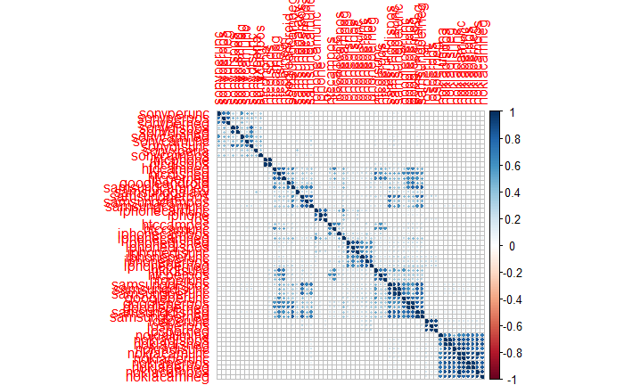

```r
# plot correlation matrix
corrplot(corrAll, order = "hclust")
```

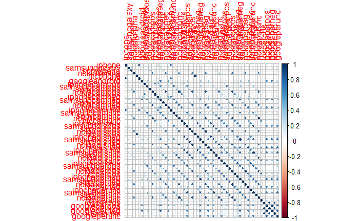

```r
corrplot(corrAll, method = "circle")
```

```r
gcorr58<- cor(galaxyCOR[,1:58])

# create object with indexes of highly corr features
gcorrIVhigh <- findCorrelation(gcorr58, cutoff=0.8)

# print indexes of highly correlated attributes
gcorrIVhigh
```

```
 [1] 29 44 24 32 56 54 34 19 42 21 31 26 51 11 36 46 16 28 23 40 57 55 30  6  5
```

```r
# get var name of high corr IV
colnames(galaxyCOR[c(29)])
```

```
[1] "samsungdisneg"
```

```r
colnames(galaxyCOR[c(44)])
```

```
[1] "samsungperneg"
```

```r
colnames(galaxyCOR[c(24)])
```

```
[1] "samsungdispos"
```

```r
colnames(galaxyCOR[c(32)])
```

```
[1] "htcdisneg"
```

```r
colnames(galaxyCOR[c(56)])
```

```
[1] "googleperneg"
```

```r
colnames(galaxyCOR[c(54)])
```

```
[1] "googleperpos"
```

```r
colnames(galaxyCOR[c(34)])
```

```
[1] "samsungdisunc"
```

```r
colnames(galaxyCOR[c(19)])
```

```
[1] "samsungcamunc"
```

```r
colnames(galaxyCOR[c(42)])
```

```
[1] "htcperpos"
```

```r
colnames(galaxyCOR[c(21)])
```

```
[1] "nokiacamunc"
```

```r
colnames(galaxyCOR[c(31)])
```

```
[1] "nokiadisneg"
```

```r
colnames(galaxyCOR[c(26)])
```

```
[1] "nokiadispos"
```

```r
colnames(galaxyCOR[c(51)])
```

```
[1] "nokiaperunc"
```

```r
colnames(galaxyCOR[c(11)])
```

```
[1] "nokiacampos"
```

```r
colnames(galaxyCOR[c(36)])
```

```
[1] "nokiadisunc"
```

```r
colnames(galaxyCOR[c(46)])
```

```
[1] "nokiaperneg"
```

```r
colnames(galaxyCOR[c(16)])
```

```
[1] "nokiacamneg"
```

```r
colnames(galaxyCOR[c(28)])
```

```
[1] "iphonedisneg"
```

```r
colnames(galaxyCOR[c(23)])
```

```
[1] "iphonedispos"
```

```r
colnames(galaxyCOR[c(40)])
```

```
[1] "sonyperpos"
```

```r
colnames(galaxyCOR[c(57)])
```

```
[1] "iosperunc"
```

```r
colnames(galaxyCOR[c(55)])
```

```
[1] "iosperneg"
```

```r
colnames(galaxyCOR[c(30)])
```

```
[1] "sonydisneg"
```

```r
colnames(galaxyCOR[c(6)])
```

```
[1] "ios"
```

```r
colnames(galaxyCOR[c(5)])
```

```
[1] "htcphone"
```

```r
#################
# Feature removal
#################

# remove based on Feature Engineering (FE)
# create 34v ds
galaxyCOR34v<- galaxyCOR
galaxyCOR34v$samsungdisneg <- NULL
galaxyCOR34v$samsungperneg<- NULL
galaxyCOR34v$samsungdispos <- NULL
galaxyCOR34v$htcdisneg<- NULL
galaxyCOR34v$googleperneg<- NULL
galaxyCOR34v$googleperpos <- NULL
galaxyCOR34v$samsungdisunc <- NULL
galaxyCOR34v$samsungcamunc <- NULL
galaxyCOR34v$htcperpos <- NULL
galaxyCOR34v$nokiacamunc <- NULL
galaxyCOR34v$nokiadisneg <- NULL
galaxyCOR34v$nokiadispos <- NULL
galaxyCOR34v$nokiaperunc <- NULL
galaxyCOR34v$nokiacampos <- NULL
galaxyCOR34v$nokiadisunc <- NULL
galaxyCOR34v$nokiaperneg <- NULL
galaxyCOR34v$nokiacamneg <- NULL
galaxyCOR34v$iphonedisneg <- NULL
galaxyCOR34v$iphonedispos <- NULL
galaxyCOR34v$sonyperpos <- NULL
galaxyCOR34v$iosperunc <- NULL
galaxyCOR34v$sonydisneg <- NULL
galaxyCOR34v$iosperneg <- NULL
galaxyCOR34v$ios <- NULL
galaxyCOR34v$htcphone <- NULL
str(galaxyCOR34v)
```

```
'data.frame':   12911 obs. of  34 variables:
 $ iphone         : num  -0.199 -0.199 -0.199 -0.364 -0.199 ...
 $ samsunggalaxy  : num  -0.254 -0.254 3.302 -0.254 -0.254 ...
 $ sonyxperia     : num  -0.14 -0.14 -0.14 -0.14 -0.14 ...
 $ nokialumina    : num  -0.0453 -0.0453 -0.0453 -0.0453 -0.0453 ...
 $ googleandroid  : num  -0.156 -0.156 -0.156 -0.156 -0.156 ...
 $ iphonecampos   : num  -0.132 -0.132 0.324 -0.132 -0.132 ...
 $ samsungcampos  : num  -0.0754 -0.0754 1.3288 -0.0754 -0.0754 ...
 $ sonycampos     : num  -0.0606 -0.0606 -0.0606 -0.0606 -0.0606 ...
 $ htccampos      : num  -0.0706 -0.0706 -0.0706 -0.0706 -0.0706 ...
 $ iphonecamneg   : num  -0.246 -0.246 -0.246 -0.246 -0.246 ...
 $ samsungcamneg  : num  -0.103 -0.103 -0.103 -0.103 -0.103 ...
 $ sonycamneg     : num  -0.0272 -0.0272 -0.0272 -0.0272 -0.0272 ...
 $ htccamneg      : num  -0.134 -0.134 -0.134 -0.134 -0.134 ...
 $ iphonecamunc   : num  -0.204 -0.204 -0.204 -0.204 -0.204 ...
```

[output cut: 20 more lines]

```r
##################
# Train/test sets
##################
# set random seed
set.seed(123)

# create the training partition 70% of total obs
ginTrainingCOR <- createDataPartition(galaxyCOR34v$galaxysentiment, p=0.7, list=FALSE)

# create training/testing dataset
gtrainSetCOR <- galaxyCOR34v[ginTrainingCOR,]
gtestSetCOR <- galaxyCOR34v[-ginTrainingCOR,]

# verify number of obs
nrow(gtrainSetCOR)
```

```
[1] 9040
```

```r
nrow(gtestSetCOR)
```

```
[1] 3871
```

```r
################
# Train control
################

# set 5 fold cross validation
fitControl <- trainControl(method = "cv", number = 5, repeats = 5)
```

```
`repeats` has no meaning for this resampling method.
```

```r
# train/fit

set.seed(123)
rf_FitCORg <- train(galaxysentiment~., data=gtrainSetCOR, method="rf", trControl=fitControl, metric = "Kappa",tuneLength=5)
rf_FitCORg
```

```
Random Forest

9040 samples
  33 predictor
   6 classes: '0', '1', '2', '3', '4', '5'

No pre-processing
Resampling: Cross-Validated (5 fold)
Summary of sample sizes: 7232, 7232, 7232, 7232, 7232
Resampling results across tuning parameters:

  mtry  Accuracy   Kappa
   2    0.6987832  0.3379076
   9    0.7501106  0.4949911
  17    0.7467920  0.4910961
  25    0.7431416  0.4863913
  33    0.7396018  0.4816743

Kappa was used to select the optimal model using the largest value.
The final value used for the model was mtry = 9.
```

```r
# Save the model
saveRDS(rf_FitCORg, "rf_FitCORg.rds")

# load and name model
rf_FitCORg <- readRDS("rf_FitCORg.rds")

#################
# Predict testSet
#################

# predict with rf
rf_Pred2g <- predict(rf_FitCORg, gtestSetCOR)
rf_Pred2g
```

[output not shown]

[output cut: 48 more lines]

```r
# summarize predictions
summary(rf_Pred2g)
```

```
   0    1    2    3    4    5
 393    2   18  201  129 3128
```

```r
# performance measurement
postResample(rf_Pred2g, gtestSetCOR$galaxysentiment)
```

```
 Accuracy     Kappa
0.7509687 0.4920602
```

```r
# calculate confusion Matrix
cmrfgcor <-confusionMatrix(rf_Pred2g,gtestSetCOR$galaxysentiment)
```

## 6.2 Method 2 - Feature Variance

```r
##########################################
# RF Model - Method 2 - Feature Variance #
##########################################

#nearZeroVar() with saveMetrics = TRUE returns an object containing a table including: frequency ratio, percentage unique, zero variance and near zero variance

gnzvMetrics <- nearZeroVar(galaxy_smallmatrix_N, saveMetrics = TRUE)
gnzvMetrics
```

|  | freqRatio | percentUnique | zeroVar | nzv |
| --- | --- | --- | --- | --- |
| iphone | 5.039313 | 0.20912400 | FALSE | FALSE |
| samsunggalaxy | 14.090164 | 0.05421733 | FALSE | FALSE |
| sonyxperia | 44.111888 | 0.03872667 | FALSE | TRUE |
| nokialumina | 495.500000 | 0.02323600 | FALSE | TRUE |
| htcphone | 11.427740 | 0.06970800 | FALSE | FALSE |
| ios | 27.662132 | 0.04647200 | FALSE | TRUE |
| googleandroid | 61.248780 | 0.04647200 | FALSE | TRUE |
| iphonecampos | 10.526217 | 0.23236000 | FALSE | FALSE |
| samsungcampos | 93.176471 | 0.08519867 | FALSE | TRUE |
| sonycampos | 347.081081 | 0.05421733 | FALSE | TRUE |

[output cut: 49 more lines]

```r
# nearZeroVar() with saveMetrics = FALSE returns an vector
gnzv <- nearZeroVar(galaxy_smallmatrix_N, saveMetrics = FALSE)
gnzv
```

```
 [1]  3  4  6  7  9 10 11 12 13 14 15 16 17 19 20 21 22 24 25 26 27 29 30 31 32 34 35 36 37 39 40 41 42 44 45 46 47 49 50 51 52 53
[43] 54 55 56 57 58
```

```r
# create a new data set and remove near zero variance features
galaxyNZV <- galaxy_smallmatrix_N[,-gnzv]
str(galaxyNZV)
```

```
'data.frame':   12911 obs. of  12 variables:
 $ iphone         : num  -0.199 -0.199 -0.199 -0.364 -0.199 ...
 $ samsunggalaxy  : num  -0.254 -0.254 3.302 -0.254 -0.254 ...
 $ htcphone       : num  -0.0325 -0.0325 -0.0325 0.2037 -0.0325 ...
 $ iphonecampos   : num  -0.132 -0.132 0.324 -0.132 -0.132 ...
 $ iphonecamunc   : num  -0.204 -0.204 -0.204 -0.204 -0.204 ...
 $ iphonedispos   : num  -0.2469 0.0977 -0.2469 -0.2469 -0.2469 ...
 $ iphonedisneg   : num  -0.219 0.141 -0.219 -0.219 -0.219 ...
 $ iphonedisunc   : num  -0.233 0.228 -0.233 -0.233 -0.233 ...
 $ iphoneperpos   : num  -0.336 -0.336 -0.336 -0.336 -0.336 ...
 $ iphoneperneg   : num  -0.291 -0.291 -0.291 -0.291 -0.291 ...
 $ iphoneperunc   : num  -0.266 -0.266 -0.266 -0.266 -0.266 ...
 $ galaxysentiment: Factor w/ 6 levels "0","1","2","3",..: 6 4 4 1 2 1 4 6 6 6 ...
```

```r
##################
# Train/test sets
##################
# set random seed
set.seed(123)

# create the training partition 70 % of total obs
ginTrainingNZV <- createDataPartition(galaxyNZV$galaxysentiment, p=0.7, list=FALSE)

# create training/testing dataset
gtrainSetNZV <- galaxyNZV[ginTrainingNZV,]
gtestSetNZV <- galaxyNZV[-ginTrainingNZV,]

# verify number of obs
nrow(gtrainSetNZV)
```

```
[1] 9040
```

```r
nrow(gtestSetNZV)
```

```
[1] 3871
```

```r
################
# Train control
################

# set 5 fold cross validation
fitControl <- trainControl(method = "cv", number = 5, repeats =5)
```

```
`repeats` has no meaning for this resampling method.
```

```r
# train/fit
set.seed(123)
grf_FitNZV <- train(galaxysentiment~., data=gtrainSetNZV, method="rf", trControl=fitControl, metric = "Kappa",tuneLength=5)
grf_FitNZV
```

```
Random Forest

9040 samples
  11 predictor
   6 classes: '0', '1', '2', '3', '4', '5'

No pre-processing
Resampling: Cross-Validated (5 fold)
Summary of sample sizes: 7232, 7232, 7232, 7232, 7232
Resampling results across tuning parameters:

  mtry  Accuracy   Kappa
   2    0.7544248  0.4997464
   4    0.7540929  0.5039358
   6    0.7516593  0.5015121
   8    0.7493363  0.4985494
  11    0.7448009  0.4927602

Kappa was used to select the optimal model using the largest value.
The final value used for the model was mtry = 4.
```

```r
# Save the Model #
saveRDS(grf_FitNZV, "grf_FitNZV.rds")

# load and name model
grf_FitNZV<- readRDS("grf_FitNZV.rds")

#################
# Predict testSet
#################
# predict with rf
rf_Pred3g <- predict(grf_FitNZV, gtestSetNZV)
rf_Pred3g
```

[output not shown]

[output cut: 48 more lines]

```r
# summarize predictions
summary(rf_Pred3g)
```

```
   0    1    2    3    4    5
 418    2    2  197  147 3105
```

```r
# performance measurement
postResample(rf_Pred3g, gtestSetNZV$galaxysentiment)
```

```
 Accuracy     Kappa
0.7548437 0.5024674
```

```r
# calculate confusion Matrix
cmrfgnzv <-confusionMatrix(rf_Pred3g,gtestSetNZV$galaxysentiment)
```

## 6.3 Method 3 - Feature Elimination

```r
#############################################
# RF Model - Method 3 - Feature Elimination #
#############################################

# Let's sample the data before using RFE
set.seed(123)
galaxySample <- galaxy_smallmatrix_N[sample(1:nrow(galaxy_smallmatrix_N), 1000, replace=FALSE),]

# Set up rfeControl with randomforest, repeated cross validation and no updates
ctrl <- rfeControl(functions = rfFuncs,
                   method = "cv",
                   repeats = 5,
                   verbose = FALSE)

# Use rfe and omit the response variable (attribute 59 galaxysentiment)
rfeResultsg <- rfe(galaxySample[,1:58],
                  galaxySample$galaxysentiment,
                  sizes=(1:58),
                  rfeControl=ctrl)

# Get results
rfeResultsg
```

```
Recursive feature selection

Outer resampling method: Cross-Validated (10 fold)

Resampling performance over subset size:
```

|  | Variables | Accuracy | Kappa | AccuracySD | KappaSD | Selected |
| --- | --- | --- | --- | --- | --- | --- |
| 1 | 1 | 0.7071 | 0.3071 | 0.02030 | 0.05977 |  |
| 2 | 2 | 0.7142 | 0.3331 | 0.02475 | 0.07531 |  |
| 3 | 3 | 0.7202 | 0.3580 | 0.02528 | 0.08070 |  |
| 4 | 4 | 0.7372 | 0.4011 | 0.03080 | 0.09395 |  |
| 5 | 5 | 0.7372 | 0.4025 | 0.03080 | 0.09383 |  |
| 6 | 6 | 0.7372 | 0.4030 | 0.03080 | 0.09443 |  |
| 7 | 7 | 0.7372 | 0.4023 | 0.03080 | 0.09398 |  |
| 8 | 8 | 0.7372 | 0.4055 | 0.03334 | 0.09661 |  |
| 9 | 9 | 0.7432 | 0.4369 | 0.03275 | 0.08876 |  |
| 10 | 10 | 0.7482 | 0.4518 | 0.03103 | 0.08084 |  |

[output cut: 48 more lines]

```
The top 5 variables (out of 18):
   iphone, samsunggalaxy, googleandroid, htcphone, iphonedisunc
```

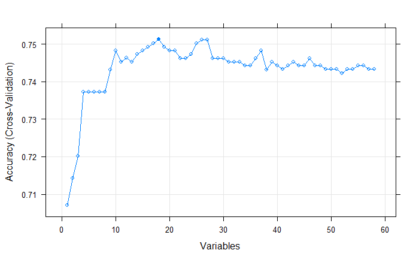

```r
# Save the Model
saveRDS(rfeResultsg, "rfeResultsg.rds")

# load and name model
rfeResultsg<- readRDS("rfeResultsg.rds")

# Plot results
plot(rfeResultsg, type=c("g", "o"))
```

```r
# create new data set with rfe recommended features
galaxyRFE <- galaxy_smallmatrix_N[,predictors(rfeResultsg)]

# add the dependent variable to iphoneRFE
galaxyRFE$galaxysentiment <- galaxy_smallmatrix_N$galaxysentiment
str(galaxyRFE)
```

```
'data.frame':   12911 obs. of  19 variables:
 $ iphone         : num  -0.199 -0.199 -0.199 -0.364 -0.199 ...
 $ samsunggalaxy  : num  -0.254 -0.254 3.302 -0.254 -0.254 ...
 $ googleandroid  : num  -0.156 -0.156 -0.156 -0.156 -0.156 ...
 $ htcphone       : num  -0.0325 -0.0325 -0.0325 0.2037 -0.0325 ...
 $ iphonedisunc   : num  -0.233 0.228 -0.233 -0.233 -0.233 ...
 $ sonyxperia     : num  -0.14 -0.14 -0.14 -0.14 -0.14 ...
 $ ios            : num  -0.182 -0.182 -0.182 -0.182 -0.182 ...
 $ iphonedispos   : num  -0.2469 0.0977 -0.2469 -0.2469 -0.2469 ...
 $ iphoneperpos   : num  -0.336 -0.336 -0.336 -0.336 -0.336 ...
 $ iphoneperneg   : num  -0.291 -0.291 -0.291 -0.291 -0.291 ...
 $ iphonecampos   : num  -0.132 -0.132 0.324 -0.132 -0.132 ...
 $ htcdispos      : num  -0.0365 -0.0365 -0.0365 0.1944 -0.0365 ...
 $ iphonedisneg   : num  -0.219 0.141 -0.219 -0.219 -0.219 ...
 $ iphonecamunc   : num  -0.204 -0.204 -0.204 -0.204 -0.204 ...
 $ iphoneperunc   : num  -0.266 -0.266 -0.266 -0.266 -0.266 ...
 $ htccampos      : num  -0.0706 -0.0706 -0.0706 -0.0706 -0.0706 ...
 $ htcperpos      : num  -0.11 -0.11 -0.11 0.749 -0.11 ...
 $ iphonecamneg   : num  -0.246 -0.246 -0.246 -0.246 -0.246 ...
 $ galaxysentiment: Factor w/ 6 levels "0","1","2","3",..: 6 4 4 1 2 1 4 6 6 6 ...
```

```r
head(galaxy_smallmatrix_N)
```

|  | iphone | samsunggalaxy | sonyxperia | nokialumina | htcphone | ios | googleandroid | iphonecampos | samsungcampos | sonycampos | nokiacampos | htccampos | iphonecamneg | samsungcamneg | sonycamneg | nokiacamneg | htccamneg | iphonecamunc | samsungcamunc | sonycamunc | nokiacamunc | htccamunc | iphonedispos | samsungdispos | sonydispos | nokiadispos | htcdispos | iphonedisneg | samsungdisneg | … |
| --- | --- | --- | --- | --- | --- | --- | --- | --- | --- | --- | --- | --- | --- | --- | --- | --- | --- | --- | --- | --- | --- | --- | --- | --- | --- | --- | --- | --- | --- | --- |
| 1 | -0.19920076 | -0.2536215 | -0.1404924 | -0.04532426 | -0.03247317 | -0.1816963 | -0.1555269 | -0.1318371 | -0.07536829 | -0.06057517 | -0.03020534 | -0.07058794 | -0.2459894 | -0.1034657 | -0.02724091 | -0.03188629 | -0.1335464 | -0.2038228 | -0.0933221 | -0.04152131 | -0.02835214 | -0.09724655 | -0.24688592 | -0.08209219 | -0.03300991 | -0.02692541 | -0.03646359 | -0.2186740 | -0.09122393 | … |
| 2 | -0.19920076 | -0.2536215 | -0.1404924 | -0.04532426 | -0.03247317 | -0.1816963 | -0.1555269 | -0.1318371 | -0.07536829 | -0.06057517 | -0.03020534 | -0.07058794 | -0.2459894 | -0.1034657 | -0.02724091 | -0.03188629 | -0.1335464 | -0.2038228 | -0.0933221 | -0.04152131 | -0.02835214 | -0.09724655 | 0.09767619 | -0.08209219 | -0.03300991 | -0.02692541 | -0.03646359 | 0.1410279 | -0.09122393 | … |
| 3 | -0.19920076 | 3.3017605 | -0.1404924 | -0.04532426 | -0.03247317 | -0.1816963 | -0.1555269 | 0.3241363 | 1.32878756 | -0.06057517 | -0.03020534 | -0.07058794 | -0.2459894 | -0.1034657 | -0.02724091 | -0.03188629 | -0.1335464 | -0.2038228 | -0.0933221 | -0.04152131 | -0.02835214 | -0.09724655 | -0.24688592 | -0.08209219 | -0.03300991 | -0.02692541 | -0.03646359 | -0.2186740 | -0.09122393 | … |
| 4 | -0.36391711 | -0.2536215 | -0.1404924 | -0.04532426 | 0.20373024 | -0.1816963 | -0.1555269 | -0.1318371 | -0.07536829 | -0.06057517 | -0.03020534 | -0.07058794 | -0.2459894 | -0.1034657 | -0.02724091 | -0.03188629 | -0.1335464 | -0.2038228 | -0.0933221 | -0.04152131 | -0.02835214 | -0.09724655 | -0.24688592 | -0.08209219 | -0.03300991 | -0.02692541 | 0.19442479 | -0.2186740 | -0.09122393 | … |
| 5 | -0.19920076 | -0.2536215 | -0.1404924 | -0.04532426 | -0.03247317 | -0.1816963 | -0.1555269 | -0.1318371 | -0.07536829 | -0.06057517 | -0.03020534 | -0.07058794 | -0.2459894 | -0.1034657 | -0.02724091 | -0.03188629 | -0.1335464 | -0.2038228 | -0.0933221 | -0.04152131 | -0.02835214 | -0.09724655 | -0.24688592 | -0.08209219 | -0.03300991 | -0.02692541 | -0.03646359 | -0.2186740 | -0.09122393 | … |
| 6 | -0.03448442 | -0.2536215 | -0.1404924 | -0.04532426 | -0.03247317 | -0.1816963 | -0.1555269 | 0.3241363 | -0.07536829 | -0.06057517 | -0.03020534 | -0.07058794 | -0.2459894 | -0.1034657 | -0.02724091 | -0.03188629 | -0.1335464 | -0.2038228 | -0.0933221 | -0.04152131 | -0.02835214 | -0.09724655 | -0.24688592 | -0.08209219 | -0.03300991 | -0.02692541 | -0.03646359 | -0.2186740 | -0.09122393 | … |

```r
# review outcome
str(galaxyRFE)
```

```
'data.frame':   12911 obs. of  19 variables:
 $ iphone         : num  -0.199 -0.199 -0.199 -0.364 -0.199 ...
 $ samsunggalaxy  : num  -0.254 -0.254 3.302 -0.254 -0.254 ...
 $ googleandroid  : num  -0.156 -0.156 -0.156 -0.156 -0.156 ...
 $ htcphone       : num  -0.0325 -0.0325 -0.0325 0.2037 -0.0325 ...
 $ iphonedisunc   : num  -0.233 0.228 -0.233 -0.233 -0.233 ...
 $ sonyxperia     : num  -0.14 -0.14 -0.14 -0.14 -0.14 ...
 $ ios            : num  -0.182 -0.182 -0.182 -0.182 -0.182 ...
 $ iphonedispos   : num  -0.2469 0.0977 -0.2469 -0.2469 -0.2469 ...
 $ iphoneperpos   : num  -0.336 -0.336 -0.336 -0.336 -0.336 ...
 $ iphoneperneg   : num  -0.291 -0.291 -0.291 -0.291 -0.291 ...
 $ iphonecampos   : num  -0.132 -0.132 0.324 -0.132 -0.132 ...
 $ htcdispos      : num  -0.0365 -0.0365 -0.0365 0.1944 -0.0365 ...
 $ iphonedisneg   : num  -0.219 0.141 -0.219 -0.219 -0.219 ...
 $ iphonecamunc   : num  -0.204 -0.204 -0.204 -0.204 -0.204 ...
 $ iphoneperunc   : num  -0.266 -0.266 -0.266 -0.266 -0.266 ...
 $ htccampos      : num  -0.0706 -0.0706 -0.0706 -0.0706 -0.0706 ...
 $ htcperpos      : num  -0.11 -0.11 -0.11 0.749 -0.11 ...
 $ iphonecamneg   : num  -0.246 -0.246 -0.246 -0.246 -0.246 ...
 $ galaxysentiment: Factor w/ 6 levels "0","1","2","3",..: 6 4 4 1 2 1 4 6 6 6 ...
```

```r
summary(galaxyRFE)
```

```
     iphone        samsunggalaxy     googleandroid        htcphone          iphonedisunc       sonyxperia           ios
 Min.   :-0.3639   Min.   :-0.2536   Min.   :-0.1555   Min.   : -0.03247   Min.   :-0.2329   Min.   :-0.1405   Min.   :-0.1817
 1st Qu.:-0.1992   1st Qu.:-0.2536   1st Qu.:-0.1555   1st Qu.: -0.03247   1st Qu.:-0.2329   1st Qu.:-0.1405   1st Qu.:-0.1817
 Median :-0.1992   Median :-0.2536   Median :-0.1555   Median : -0.03247   Median :-0.2329   Median :-0.1405   Median :-0.1817
 Mean   : 0.0000   Mean   : 0.0000   Mean   : 0.0000   Mean   :  0.00000   Mean   : 0.0000   Mean   : 0.0000   Mean   : 0.0000
 3rd Qu.:-0.1992   3rd Qu.:-0.2536   3rd Qu.:-0.1555   3rd Qu.: -0.03247   3rd Qu.:-0.2329   3rd Qu.:-0.1405   3rd Qu.:-0.1817
 Max.   : 7.2130   Max.   :28.1894   Max.   :23.3299   Max.   :113.10896   Max.   :35.2844   Max.   :46.5192   Max.   : 6.9559
  iphonedispos      iphoneperpos     iphoneperneg     iphonecampos       htcdispos          iphonedisneg      iphonecamunc
 Min.   :-0.2469   Min.   :-0.336   Min.   :-0.291   Min.   :-0.1318   Min.   : -0.03646   Min.   :-0.2187   Min.   :-0.2038
 1st Qu.:-0.2469   1st Qu.:-0.336   1st Qu.:-0.291   1st Qu.:-0.1318   1st Qu.: -0.03646   1st Qu.:-0.2187   1st Qu.:-0.2038
 Median :-0.2469   Median :-0.336   Median :-0.291   Median :-0.1318   Median : -0.03646   Median :-0.2187   Median :-0.2038
 Mean   : 0.0000   Mean   : 0.000   Mean   : 0.000   Mean   : 0.0000   Mean   :  0.00000   Mean   : 0.0000   Mean   : 0.0000
 3rd Qu.:-0.2469   3rd Qu.:-0.336   3rd Qu.:-0.291   3rd Qu.:-0.1318   3rd Qu.: -0.03646   3rd Qu.:-0.2187   3rd Qu.:-0.2038
 Max.   :22.4942   Max.   :25.292   Max.   :19.486   Max.   :71.0000   Max.   :110.55907   Max.   :42.9456   Max.   :35.9219
  iphoneperunc       htccampos          htcperpos        iphonecamneg    galaxysentiment
 Min.   :-0.2664   Min.   :-0.07059   Min.   :-0.1099   Min.   :-0.246   0:1696
 1st Qu.:-0.2664   1st Qu.:-0.07059   1st Qu.:-0.1099   1st Qu.:-0.246   1: 382
 Median :-0.2664   Median :-0.07059   Median :-0.1099   Median :-0.246   2: 450
 Mean   : 0.0000   Mean   : 0.00000   Mean   : 0.0000   Mean   : 0.000   3:1175
 3rd Qu.:-0.2664   3rd Qu.:-0.07059   3rd Qu.:-0.1099   3rd Qu.:-0.246   4:1417
 Max.   :27.4478   Max.   :97.24104   Max.   :55.7038   Max.   :32.280   5:7791
```

```r
##################
# Train/test sets
##################

# set random seed
set.seed(123)

# create the training partition 70 % of total obs
ginTrainingRFE <- createDataPartition(galaxyRFE$galaxysentiment, p=0.7, list=FALSE)

# create training/testing dataset
gtrainSetRFE <- galaxyRFE[ginTrainingRFE,]
gtestSetRFE <- galaxyRFE[-ginTrainingRFE,]

# verify number of obs
nrow(gtrainSetRFE)
```

```
[1] 9040
```

```r
nrow(gtestSetRFE)
```

```
[1] 3871
```

```r
################
# Train control
################

# set 5 fold cross validation
fitControl <- trainControl(method = "cv", number = 5)

# train/fit
set.seed(123)
rf_FitRFEg <- train(galaxysentiment~., data=gtrainSetRFE, method="rf", trControl=fitControl, metric = "Kappa",tuneLength=5)
rf_FitRFEg
```

```
Random Forest

9040 samples
  18 predictor
   6 classes: '0', '1', '2', '3', '4', '5'

No pre-processing
Resampling: Cross-Validated (5 fold)
Summary of sample sizes: 7232, 7232, 7232, 7232, 7232
Resampling results across tuning parameters:

  mtry  Accuracy   Kappa
   2    0.7423673  0.4648326
   6    0.7652655  0.5318984
  10    0.7629425  0.5304217
  14    0.7603982  0.5277759
  18    0.7558628  0.5206057

Kappa was used to select the optimal model using the largest value.
The final value used for the model was mtry = 6.
```

```r
# Save the model
saveRDS(rf_FitRFEg, "rf_FitRFEg.rds")

# load and name model
rf_FitRFEg <- readRDS("rf_FitRFEg.rds")

#################
# Predict testSet
#################
# predict with rf
rf_Pred5g <- predict(rf_FitRFEg, gtestSetRFE)
rf_Pred5g
```

[output not shown]

[output cut: 48 more lines]

```r
# summarize predictions
summary(rf_Pred5g)
```

```
   0    1    2    3    4    5
 399    3   21  246  138 3064
```

```r
# performance measurement
postResample(rf_Pred5g, gtestSetRFE$galaxysentiment)
```

```
 Accuracy     Kappa
0.7708602 0.5405333
```

```r
# calculate confusion Matrix
cmrfeg <-confusionMatrix(rf_Pred5g,gtestSetRFE$galaxysentiment)
```

# 7 Feature Engineering

Feature engineering is the art of working with the data so that it can more readily be consumed by machine learning algorithms. Feature engineering includes mutating existing attributes, combining attributes, deconstructing attributes and much more.

In this step we will consider two possibilities:

A- Altering the dependant variable B- Principal Component Analysis

## 7.1 Engineering the Dependant variable

1: negative 2: somewhat negative 3: somewhat positive 4: positive

```r
############################################################
# RF Model with RFE and Engineering the Dependant variable #
############################################################
# create a new dataset that will be used for recoding sentiment
galaxyRC <- galaxyRFE
# recode sentiment to combine factor levels 0 & 1 and 4 & 5
galaxyRC$galaxysentiment <- recode(galaxyRFE$galaxysentiment, '0' = 1, '1' = 1, '2' = 2, '3' = 3, '4' = 4, '5' = 4)
# inspect results
summary(galaxyRC)
```

```
     iphone        samsunggalaxy     googleandroid        htcphone          iphonedisunc       sonyxperia           ios
 Min.   :-0.3639   Min.   :-0.2536   Min.   :-0.1555   Min.   : -0.03247   Min.   :-0.2329   Min.   :-0.1405   Min.   :-0.1817
 1st Qu.:-0.1992   1st Qu.:-0.2536   1st Qu.:-0.1555   1st Qu.: -0.03247   1st Qu.:-0.2329   1st Qu.:-0.1405   1st Qu.:-0.1817
 Median :-0.1992   Median :-0.2536   Median :-0.1555   Median : -0.03247   Median :-0.2329   Median :-0.1405   Median :-0.1817
 Mean   : 0.0000   Mean   : 0.0000   Mean   : 0.0000   Mean   :  0.00000   Mean   : 0.0000   Mean   : 0.0000   Mean   : 0.0000
 3rd Qu.:-0.1992   3rd Qu.:-0.2536   3rd Qu.:-0.1555   3rd Qu.: -0.03247   3rd Qu.:-0.2329   3rd Qu.:-0.1405   3rd Qu.:-0.1817
 Max.   : 7.2130   Max.   :28.1894   Max.   :23.3299   Max.   :113.10896   Max.   :35.2844   Max.   :46.5192   Max.   : 6.9559
  iphonedispos      iphoneperpos     iphoneperneg     iphonecampos       htcdispos          iphonedisneg      iphonecamunc
 Min.   :-0.2469   Min.   :-0.336   Min.   :-0.291   Min.   :-0.1318   Min.   : -0.03646   Min.   :-0.2187   Min.   :-0.2038
 1st Qu.:-0.2469   1st Qu.:-0.336   1st Qu.:-0.291   1st Qu.:-0.1318   1st Qu.: -0.03646   1st Qu.:-0.2187   1st Qu.:-0.2038
 Median :-0.2469   Median :-0.336   Median :-0.291   Median :-0.1318   Median : -0.03646   Median :-0.2187   Median :-0.2038
 Mean   : 0.0000   Mean   : 0.000   Mean   : 0.000   Mean   : 0.0000   Mean   :  0.00000   Mean   : 0.0000   Mean   : 0.0000
 3rd Qu.:-0.2469   3rd Qu.:-0.336   3rd Qu.:-0.291   3rd Qu.:-0.1318   3rd Qu.: -0.03646   3rd Qu.:-0.2187   3rd Qu.:-0.2038
 Max.   :22.4942   Max.   :25.292   Max.   :19.486   Max.   :71.0000   Max.   :110.55907   Max.   :42.9456   Max.   :35.9219
  iphoneperunc       htccampos          htcperpos        iphonecamneg    galaxysentiment
 Min.   :-0.2664   Min.   :-0.07059   Min.   :-0.1099   Min.   :-0.246   Min.   :1.000
 1st Qu.:-0.2664   1st Qu.:-0.07059   1st Qu.:-0.1099   1st Qu.:-0.246   1st Qu.:3.000
 Median :-0.2664   Median :-0.07059   Median :-0.1099   Median :-0.246   Median :4.000
 Mean   : 0.0000   Mean   : 0.00000   Mean   : 0.0000   Mean   : 0.000   Mean   :3.356
 3rd Qu.:-0.2664   3rd Qu.:-0.07059   3rd Qu.:-0.1099   3rd Qu.:-0.246   3rd Qu.:4.000
 Max.   :27.4478   Max.   :97.24104   Max.   :55.7038   Max.   :32.280   Max.   :4.000
```

```r
str(galaxyRC)
```

```
'data.frame':   12911 obs. of  19 variables:
 $ iphone         : num  -0.199 -0.199 -0.199 -0.364 -0.199 ...
 $ samsunggalaxy  : num  -0.254 -0.254 3.302 -0.254 -0.254 ...
 $ googleandroid  : num  -0.156 -0.156 -0.156 -0.156 -0.156 ...
 $ htcphone       : num  -0.0325 -0.0325 -0.0325 0.2037 -0.0325 ...
 $ iphonedisunc   : num  -0.233 0.228 -0.233 -0.233 -0.233 ...
 $ sonyxperia     : num  -0.14 -0.14 -0.14 -0.14 -0.14 ...
 $ ios            : num  -0.182 -0.182 -0.182 -0.182 -0.182 ...
 $ iphonedispos   : num  -0.2469 0.0977 -0.2469 -0.2469 -0.2469 ...
 $ iphoneperpos   : num  -0.336 -0.336 -0.336 -0.336 -0.336 ...
 $ iphoneperneg   : num  -0.291 -0.291 -0.291 -0.291 -0.291 ...
 $ iphonecampos   : num  -0.132 -0.132 0.324 -0.132 -0.132 ...
 $ htcdispos      : num  -0.0365 -0.0365 -0.0365 0.1944 -0.0365 ...
 $ iphonedisneg   : num  -0.219 0.141 -0.219 -0.219 -0.219 ...
 $ iphonecamunc   : num  -0.204 -0.204 -0.204 -0.204 -0.204 ...
 $ iphoneperunc   : num  -0.266 -0.266 -0.266 -0.266 -0.266 ...
 $ htccampos      : num  -0.0706 -0.0706 -0.0706 -0.0706 -0.0706 ...
 $ htcperpos      : num  -0.11 -0.11 -0.11 0.749 -0.11 ...
 $ iphonecamneg   : num  -0.246 -0.246 -0.246 -0.246 -0.246 ...
 $ galaxysentiment: num  4 3 3 1 1 1 3 4 4 4 ...
```

```r
# make iphonesentiment a factor
galaxyRC$galaxysentiment <- as.factor(galaxyRC$galaxysentiment)

##################
# Train/test sets
##################

# set random seed
set.seed(123)
ginTrainingRC <- createDataPartition(galaxyRC$galaxysentiment, p=0.7, list=FALSE)
# create training/testing dataset
gtrainSetRC <- galaxyRC[ginTrainingRC,]
gtestSetRC <- galaxyRC[-ginTrainingRC,]

# verify number of obs
nrow(gtrainSetRC)
```

```
[1] 9039
```

```r
nrow(gtestSetRC)
```

```
[1] 3872
```

```r
################
# Train control
################

# set 5 fold cross validation
fitControl <- trainControl(method = "cv", number = 5)

# train/fit

set.seed(123)
rf_FitRCg <- train(galaxysentiment~., data=gtrainSetRC, method="rf", trControl=fitControl, metric = "Kappa",tuneLength=5)
rf_FitRCg
```

```
Random Forest

9039 samples
  18 predictor
   4 classes: '1', '2', '3', '4'

No pre-processing
Resampling: Cross-Validated (5 fold)
Summary of sample sizes: 7231, 7231, 7232, 7231, 7231
Resampling results across tuning parameters:

  mtry  Accuracy   Kappa
   2    0.8144709  0.4861649
   6    0.8429031  0.5930211
  10    0.8411329  0.5902488
  14    0.8391415  0.5876152
  18    0.8354903  0.5801288

Kappa was used to select the optimal model using the largest value.
The final value used for the model was mtry = 6.
```

```r
# Save the model
saveRDS(rf_FitRCg, "rf_FitRCg.rds")

# load and name model
rf_FitRCg <- readRDS("rf_FitRCg.rds")

#################
# Predict testSet
#################
# predict with rf
rf_Pred6g <- predict(rf_FitRCg, gtestSetRC)
rf_Pred6g
```

[output not shown]

[output cut: 48 more lines]

```r
# summarize predictions
summary(rf_Pred6g)
```

```
   1    2    3    4
 409   22  230 3211
```

```r
# performance measurement
postResample(rf_Pred6g, gtestSetRC$galaxysentiment)
```

```
 Accuracy     Kappa
0.8494318 0.6097790
```

```r
# calculate confusion Matrix
cmrcg <-confusionMatrix(rf_Pred6g, gtestSetRC$galaxysentiment, mode="everything")
```

## 7.2 Principal Component Analysis

Principal Component Analysis (PCA) is a form of feature engineering that removes all of your features and replaces them with mathematical representations of their variance

```r
#####################################################################
# Random Forest Model with PCA and Engineering the Dependent variable
#####################################################################

########### Train/test sets##############

# set random seed
set.seed(123)
# create the training partition 70 % of total obs
inTrainingggpca <- createDataPartition(galaxy_smallmatrix$galaxysentiment, p=0.7, list=FALSE)
# create training/testing dataset
gtraining <- galaxy_smallmatrix[inTrainingggpca,]
gtesting <- galaxy_smallmatrix[-inTrainingggpca,]
# verify number of obs
nrow(gtraining)
```

```
[1] 9040
```

```r
nrow(gtesting)
```

```
[1] 3871
```

```r
########### recode the Dependent variable##############
gtraining$galaxysentiment <- recode(gtraining$galaxysentiment, '0' = 1, '1' = 1, '2' = 2, '3' = 3, '4' = 4, '5' = 4)

gtraining$galaxysentiment <- as.factor(gtraining$galaxysentiment)

gtesting$galaxysentiment <- recode(gtesting$galaxysentiment, '0' = 1, '1' = 1, '2' = 2, '3' = 3, '4' = 4, '5' = 4)

gtesting$galaxysentiment <- as.factor(gtesting$galaxysentiment)

str(gtraining)
```

```
'data.frame':   9040 obs. of  59 variables:
 $ iphone         : int  1 1 1 0 2 1 4 1 1 1 ...
 $ samsunggalaxy  : int  0 0 1 0 0 0 0 0 0 0 ...
 $ sonyxperia     : int  0 0 0 0 0 0 0 0 0 0 ...
 $ nokialumina    : int  0 0 0 0 0 0 0 0 0 0 ...
 $ htcphone       : int  0 0 0 1 0 0 0 1 0 0 ...
 $ ios            : int  0 0 0 0 0 0 0 0 0 0 ...
 $ googleandroid  : int  0 0 0 0 0 0 0 0 0 0 ...
 $ iphonecampos   : int  0 0 1 0 1 0 0 0 0 1 ...
 $ samsungcampos  : int  0 0 1 0 0 0 0 0 0 0 ...
 $ sonycampos     : int  0 0 0 0 0 0 0 0 0 0 ...
 $ nokiacampos    : int  0 0 0 0 0 0 0 0 0 0 ...
 $ htccampos      : int  0 0 0 0 0 0 0 0 0 0 ...
 $ iphonecamneg   : int  0 0 0 0 0 0 0 0 0 1 ...
 $ samsungcamneg  : int  0 0 0 0 0 0 0 0 0 0 ...
```

[output cut: 45 more lines]

```r
### normalize and PCA ####
# data = training and testing from iphoneDF (no feature selection)
# create object containing centered, scaled PCA components from training set
# excluded the dependent variable and set threshold to .95
preprocessParamsgpca <- preProcess(gtraining[,-59], method=c("center", "scale", "pca"), thresh = 0.95)
print(preprocessParamsgpca)
```

```
Created from 9040 samples and 58 variables

Pre-processing:
  - centered (58)
  - ignored (0)
  - principal component signal extraction (58)
  - scaled (58)

PCA needed 24 components to capture 95 percent of the variance
```

```r
# use predict to apply pca parameters, create training, exclude dependant
gtrain.pca <- predict(preprocessParamsgpca, gtraining[,-59])

# add the dependent to training
gtrain.pca$galaxysentiment <- gtraining$galaxysentiment

# use predict to apply pca parameters, create testing, exclude dependant
gtest.pca <- predict(preprocessParamsgpca, gtesting[,-59])

# add the dependent to training
gtest.pca$galaxysentiment <- gtesting$galaxysentiment

# inspect results
str(gtrain.pca)
```

```
'data.frame':   9040 obs. of  25 variables:
 $ PC1            : num  -0.654 -0.546 -0.158 0.145 -0.621 ...
 $ PC2            : num  0.049 0.0087 -0.0568 -0.1844 0.0356 ...
 $ PC3            : num  -0.593 -0.195 -1.011 -0.582 -0.494 ...
 $ PC4            : num  0.161 0.15 -0.114 0.23 0.153 ...
 $ PC5            : num  -0.0323 -0.1478 -0.0526 0.7839 0.0915 ...
 $ PC6            : num  0.1651 0.1175 -0.3737 1.3076 0.0913 ...
 $ PC7            : num  0.1151 0.3488 -0.1403 0.1833 0.0846 ...
 $ PC8            : num  0.06689 -0.00114 -0.64421 0.72529 0.07808 ...
 $ PC9            : num  -0.00886 0.03387 0.23841 -0.06964 0.00195 ...
 $ PC10           : num  0.0437 0.0293 -0.3577 0.0614 0.0119 ...
 $ PC11           : num  0.00311 -0.01174 0.69114 -0.03308 0.10306 ...
 $ PC12           : num  -0.1291 -0.105 0.4896 0.0267 -0.1748 ...
 $ PC13           : num  0.0723 -0.0904 -0.1087 -0.7347 0.2593 ...
 $ PC14           : num  -0.185 -0.14 2.106 -0.105 -0.178 ...
 $ PC15           : num  -0.0585 -0.0147 1.216 -0.0362 -0.0506 ...
 $ PC16           : num  -0.12707 -0.47078 0.21796 0.00282 -0.12971 ...
 $ PC17           : num  0.053 0.1919 -0.4575 0.1339 0.0928 ...
 $ PC18           : num  0.00631 -0.10374 -0.78125 0.18351 0.02268 ...
 $ PC19           : num  -0.00734 0.05502 -0.13282 0.01602 -0.02296 ...
 $ PC20           : num  0.0011 0.00613 0.49896 0.53708 0.10211 ...
 $ PC21           : num  0.0178 0.023 0.5132 -0.0428 0.0311 ...
 $ PC22           : num  0.00822 0.01577 -1.38011 -0.10169 -0.00295 ...
 $ PC23           : num  -0.0378 -0.0466 0.4835 -0.1019 -0.0752 ...
 $ PC24           : num  -0.06945 -0.07289 0.11028 0.34183 -0.00476 ...
 $ galaxysentiment: Factor w/ 4 levels "1","2","3","4": 4 3 3 1 1 4 4 4 4 4 ...
```

```r
str(gtest.pca)
```

```
'data.frame':   3871 obs. of  25 variables:
 $ PC1            : num  -0.654 -0.591 -0.654 -0.597 -0.594 ...
 $ PC2            : num  0.049 0.0252 0.049 0.0245 0.0312 ...
 $ PC3            : num  -0.593 -0.359 -0.593 -0.391 -0.418 ...
 $ PC4            : num  0.161 0.155 0.161 0.156 0.156 ...
 $ PC5            : num  -0.0323 -0.0997 -0.0323 0.0182 -0.0888 ...
 $ PC6            : num  0.165 0.174 0.165 -0.08 0.221 ...
 $ PC7            : num  0.115 0.26 0.115 0.132 0.127 ...
 $ PC8            : num  0.0669 -0.0158 0.0669 0.2336 -0.0143 ...
 $ PC9            : num  -0.00886 0.02417 -0.00886 -0.02812 0.00173 ...
 $ PC10           : num  0.0437 0.0263 0.0437 0.0523 0.027 ...
 $ PC11           : num  0.00311 0.01722 0.00311 -0.0302 0.04074 ...
 $ PC12           : num  -0.129 -0.132 -0.129 -0.108 -0.153 ...
 $ PC13           : num  0.0723 0.0179 0.0723 -0.0201 0.1395 ...
 $ PC14           : num  -0.185 -0.155 -0.185 -0.144 -0.189 ...
 $ PC15           : num  -0.0585 -0.0421 -0.0585 -0.0665 -0.0768 ...
 $ PC16           : num  -0.1271 -0.3092 -0.1271 -0.175 0.0828 ...
 $ PC17           : num  0.053 0.1277 0.053 0.0471 -0.0393 ...
 $ PC18           : num  0.00631 -0.04742 0.00631 -0.02004 0.07185 ...
 $ PC19           : num  -0.00734 0.04761 -0.00734 0.12253 0.04089 ...
 $ PC20           : num  0.0011 0.00788 0.0011 -0.13682 -0.05516 ...
 $ PC21           : num  0.0178 0.0196 0.0178 0.0581 0.0437 ...
 $ PC22           : num  0.00822 0.00309 0.00822 -0.0022 0.00229 ...
 $ PC23           : num  -0.0378 -0.0492 -0.0378 -0.0971 -0.0871 ...
 $ PC24           : num  -0.069453 -0.031996 -0.069453 -0.040366 -0.000816 ...
 $ galaxysentiment: Factor w/ 4 levels "1","2","3","4": 1 3 4 1 1 1 4 4 3 1 ...
```

```r
################
# Train control
################

# set 5 fold cross validation
fitControl <- trainControl(method = "cv", number = 5)

# train/fit

set.seed(123)
rf_Fitpcag<- train(galaxysentiment~., data=gtrain.pca, method="rf", trControl=fitControl, metric = "Kappa",tuneLength=5)
rf_Fitpcag
```

```
Random Forest

9040 samples
  24 predictor
   4 classes: '1', '2', '3', '4'

No pre-processing
Resampling: Cross-Validated (5 fold)
Summary of sample sizes: 7232, 7232, 7232, 7232, 7232
Resampling results across tuning parameters:

  mtry  Accuracy   Kappa
   2    0.8341814  0.5750448
   7    0.8342920  0.5750195
  13    0.8339602  0.5742695
  18    0.8334071  0.5727174
  24    0.8331858  0.5718174

Kappa was used to select the optimal model using the largest value.
The final value used for the model was mtry = 2.
```

```r
# Save the model
saveRDS(rf_Fitpcag, "rf_Fitpcag.rds")

# load and name model
rf_Fitpcag <- readRDS("rf_Fitpcag.rds")

#################
# Predict testSet
#################
# predict with rf
rf_Pred7g <- predict(rf_Fitpcag, gtest.pca)
rf_Pred7g
```

[output not shown]

[output cut: 48 more lines]

```r
# summarize predictions
summary(rf_Pred7g)
```

```
   1    2    3    4
 414   23  238 3196
```

```r
# performance measurement
postResample(rf_Pred7g, gtest.pca$galaxysentiment)
```

```
 Accuracy     Kappa
0.8411263 0.5904514
```

```r
# calculate confusion Matrix
options(max.print=10000)
cmrf <-confusionMatrix(rf_Pred7g,gtest.pca$galaxysentiment, mode="everything")
cmrf
```

```
Confusion Matrix and Statistics

          Reference
Prediction    1    2    3    4
         1  352    5    4   53
         2    1   17    0    5
         3    5    0  208   25
         4  264  113  140 2679

Overall Statistics

               Accuracy : 0.8411
                 95% CI : (0.8292, 0.8525)
    No Information Rate : 0.7135
    P-Value [Acc > NIR] : < 2.2e-16

                  Kappa : 0.5905

 Mcnemar's Test P-Value : NA

Statistics by Class:

                     Class: 1 Class: 2 Class: 3 Class: 4
Sensitivity           0.56592 0.125926  0.59091   0.9699
Specificity           0.98092 0.998394  0.99147   0.5338
Pos Pred Value        0.85024 0.739130  0.87395   0.8382
Neg Pred Value        0.92190 0.969335  0.96036   0.8770
Precision             0.85024 0.739130  0.87395   0.8382
Recall                0.56592 0.125926  0.59091   0.9699
F1                    0.67954 0.215190  0.70508   0.8993
Prevalence            0.16068 0.034875  0.09093   0.7135
Detection Rate        0.09093 0.004392  0.05373   0.6921
Detection Prevalence  0.10695 0.005942  0.06148   0.8256
Balanced Accuracy     0.77342 0.562160  0.79119   0.7519
```

# 8 Sentiment Analysis in Large Data Matrix

## 8.1 Feature Engineering

```r
########################################
# Feature Engineering with large matrix
########################################

# create new data set with rfe recommended features
galaxylargematrixRFE <- galaxy_largematrix_N[,predictors(rfeResultsg)]

# add the dependent variable to iphoneRFE
galaxylargematrixRFE$galaxysentiment <- galaxy_largematrix_N$galaxysentiment
str(galaxylargematrixRFE)
```

```
'data.frame':   32226 obs. of  19 variables:
 $ iphone         : num  -0.364 -0.364 -0.364 -0.364 -0.364 ...
 $ samsunggalaxy  : num  -0.254 -0.254 -0.254 -0.254 -0.254 ...
 $ googleandroid  : num  -0.156 -0.156 -0.156 -0.156 -0.156 ...
 $ htcphone       : num  -0.0325 -0.0325 -0.0325 -0.0325 -0.0325 ...
 $ iphonedisunc   : num  -0.233 -0.233 -0.233 -0.233 -0.233 ...
 $ sonyxperia     : num  -0.14 -0.14 -0.14 -0.14 -0.14 ...
 $ ios            : num  -0.182 -0.182 -0.182 -0.182 -0.182 ...
 $ iphonedispos   : num  -0.247 -0.247 -0.247 -0.247 -0.247 ...
 $ iphoneperpos   : num  -0.336 -0.336 -0.336 -0.336 -0.336 ...
 $ iphoneperneg   : num  -0.291 -0.291 -0.291 -0.291 -0.291 ...
 $ iphonecampos   : num  -0.132 -0.132 -0.132 -0.132 -0.132 ...
 $ htcdispos      : num  -0.0365 -0.0365 -0.0365 -0.0365 -0.0365 ...
 $ iphonedisneg   : num  -0.219 -0.219 -0.219 -0.219 -0.219 ...
 $ iphonecamunc   : num  -0.204 -0.204 -0.204 -0.204 -0.204 ...
 $ iphoneperunc   : num  -0.266 -0.266 -0.266 -0.266 -0.266 ...
 $ htccampos      : num  -0.0706 -0.0706 -0.0706 -0.0706 -0.0706 ...
 $ htcperpos      : num  -0.11 -0.11 -0.11 -0.11 -0.11 ...
 $ iphonecamneg   : num  -0.246 -0.246 -0.246 -0.246 -0.246 ...
 $ galaxysentiment: Factor w/ 0 levels: NA NA NA NA NA NA NA NA NA NA ...
```

## 8.2 Prediction

```r
####################
# Predict new dataSet
####################
# predict with rf
rf_Pred8g <- predict(rf_FitRCg, galaxylargematrixRFE)
rf_Pred8g
```

[output not shown]

[output cut: 149 more lines]

```r
# summarize predictions
summary(rf_Pred8g)
```

```
    1     2     3     4
13107  1011  2058 16050
```

```r
###############
# Save datasets
###############
galaxy_largematrixoutput <- galaxy_largematrix
galaxy_largematrixoutput$galaxysentiment<- rf_Pred8g
write.csv(galaxy_largematrixoutput, file = "galaxy_largematrixoutput.csv")
```

# 9 Model Recomendation

Based on the outcomes of this modeling process, the following configuration was the most suitable in terms of quality metrics (Kappa and Accuracy).

Algorithm: Random Forest Feature Selection: Recursive Feature Elimination Feature Engineering: Engineering the Dependant variable

```r
### Performance Metrics ###

# Modeling Metrics
ModelFitResultgalaxy <- resamples(list(C5.0=C5.0_Fitg,rf=rf_Fitg,SVM=svm_Fitg,kknn=kknn_Fitg,gbm=gbm_Fit3g))
# output summary metrics for tuned models
summary(ModelFitResultgalaxy)
```

```
Call:
summary.resamples(object = ModelFitResultgalaxy)

Models: C5.0, rf, SVM, kknn, gbm
Number of resamples: 5

Accuracy
          Min.   1st Qu.    Median      Mean   3rd Qu.      Max. NA's
C5.0 0.7605088 0.7616150 0.7638274 0.7641593 0.7660398 0.7688053    0
rf   0.7588496 0.7616150 0.7676991 0.7657080 0.7682522 0.7721239    0
SVM  0.6852876 0.6991150 0.7018805 0.7024336 0.7035398 0.7223451    0
kknn 0.6913717 0.7063053 0.7472345 0.7300885 0.7516593 0.7538717    0
gbm  0.7577434 0.7649336 0.7654867 0.7650442 0.7660398 0.7710177    0

Kappa
          Min.   1st Qu.    Median      Mean   3rd Qu.      Max. NA's
C5.0 0.5201444 0.5211200 0.5266023 0.5269740 0.5285588 0.5384445    0
rf   0.5139824 0.5189964 0.5359479 0.5308090 0.5365963 0.5485222    0
SVM  0.3319280 0.3666704 0.3781816 0.3764809 0.3889450 0.4166797    0
kknn 0.4334440 0.4596445 0.5081411 0.4857298 0.5111993 0.5162200    0
gbm  0.5109802 0.5248205 0.5320860 0.5293069 0.5335027 0.5451451    0
```

```r
# Feature Selection
Featureselectiongalaxy <- resamples(list(Correlation=rf_FitCORg,NZV=grf_FitNZV,RFE=rf_FitRFEg))
# output summary metrics for feature selection
summary(Featureselectiongalaxy)
```

```
Call:
summary.resamples(object = Featureselectiongalaxy)

Models: Correlation, NZV, RFE
Number of resamples: 5

Accuracy
                 Min.   1st Qu.    Median      Mean   3rd Qu.      Max. NA's
Correlation 0.7417035 0.7444690 0.7472345 0.7501106 0.7577434 0.7594027    0
NZV         0.7522124 0.7527655 0.7527655 0.7540929 0.7560841 0.7566372    0
RFE         0.7582965 0.7599558 0.7682522 0.7652655 0.7688053 0.7710177    0

Kappa
                 Min.   1st Qu.    Median      Mean   3rd Qu.      Max. NA's
Correlation 0.4748952 0.4784247 0.4923152 0.4949911 0.5108428 0.5184777    0
NZV         0.4989103 0.4998422 0.4999247 0.5039358 0.5091681 0.5118338    0
RFE         0.5155882 0.5180784 0.5388547 0.5318984 0.5396414 0.5473292    0
```

```r
# Feature Engineering
Featureengineeringgalaxy <- resamples(list(DV=rf_FitRCg,PCA=rf_Fitpcag))
# output summary metrics for feature engineering
summary(Featureengineeringgalaxy)
```

```
Call:
summary.resamples(object = Featureengineeringgalaxy)

Models: DV, PCA
Number of resamples: 5

Accuracy
         Min.   1st Qu.    Median      Mean   3rd Qu.      Max. NA's
DV  0.8379425 0.8418142 0.8434735 0.8429031 0.8439402 0.8473451    0
PCA 0.8224558 0.8324115 0.8340708 0.8341814 0.8401549 0.8418142    0

Kappa
         Min.   1st Qu.    Median      Mean  3rd Qu.      Max. NA's
DV  0.5733892 0.5935039 0.5939462 0.5930211 0.598923 0.6053432    0
PCA 0.5497484 0.5726442 0.5780321 0.5750448 0.586998 0.5878014    0
```

```r
stopCluster(cl)
```

End of the document

—— SML ——–